# CPE-695 Team 5 Spaceship Titanic Source Code

Links to data: [test](https://www.kaggle.com/competitions/spaceship-titanic/data?select=test.csv), [train](https://www.kaggle.com/competitions/spaceship-titanic/data?select=train.csv)

### Exploratory Data Analysis & Data Preprocessing - Anna

Importing necessary libraries

```python
import os
import numpy as np
import pandas as pd
from sklearn.inspection import permutation_importance
import seaborn as sns
from sklearn.metrics import roc_curve
import matplotlib.pyplot as plt
from sklearn.preprocessing import StandardScaler
from sklearn.model_selection import train_test_split
import plotly_express as px
from sklearn.linear_model import LogisticRegression
from sklearn.metrics import confusion_matrix, classification_report
import warnings
from sklearn.metrics import roc_auc_score
from sklearn.tree import DecisionTreeClassifier
from sklearn.ensemble import RandomForestClassifier
from sklearn.naive_bayes import GaussianNB
from sklearn.model_selection import GridSearchCV
from sklearn.tree import export_graphviz
import graphviz
from sklearn.metrics import precision_recall_curve
warnings.filterwarnings("ignore")
```

Reading the data sets

```python
train_df = pd.read_csv("downloads/train.csv")
test_df = pd.read_csv("downloads/test.csv")
```

Taking a look at the first few rows of the data to see what the variables are and some values

```python
train_df.head()
```

|  | PassengerId | HomePlanet | CryoSleep | Cabin | Destination | Age | VIP | RoomService | FoodCourt | ShoppingMall | Spa | VRDeck | Name | Transported |
| --- | --- | --- | --- | --- | --- | --- | --- | --- | --- | --- | --- | --- | --- | --- |
| 0 | 0001_01 | Europa | False | B/0/P | TRAPPIST-1e | 39.0 | False | 0.0 | 0.0 | 0.0 | 0.0 | 0.0 | Maham Ofracculy | False |
| 1 | 0002_01 | Earth | False | F/0/S | TRAPPIST-1e | 24.0 | False | 109.0 | 9.0 | 25.0 | 549.0 | 44.0 | Juanna Vines | True |
| 2 | 0003_01 | Europa | False | A/0/S | TRAPPIST-1e | 58.0 | True | 43.0 | 3576.0 | 0.0 | 6715.0 | 49.0 | Altark Susent | False |
| 3 | 0003_02 | Europa | False | A/0/S | TRAPPIST-1e | 33.0 | False | 0.0 | 1283.0 | 371.0 | 3329.0 | 193.0 | Solam Susent | False |
| 4 | 0004_01 | Earth | False | F/1/S | TRAPPIST-1e | 16.0 | False | 303.0 | 70.0 | 151.0 | 565.0 | 2.0 | Willy Santantines | True |

Checking the column types

```python
train_df.info()
```

```
<class 'pandas.core.frame.DataFrame'>
RangeIndex: 8693 entries, 0 to 8692
Data columns (total 14 columns):
 #   Column        Non-Null Count  Dtype
---  ------        --------------  -----
 0   PassengerId   8693 non-null   object
 1   HomePlanet    8492 non-null   object
 2   CryoSleep     8476 non-null   object
 3   Cabin         8494 non-null   object
 4   Destination   8511 non-null   object
 5   Age           8514 non-null   float64
 6   VIP           8490 non-null   object
 7   RoomService   8512 non-null   float64
 8   FoodCourt     8510 non-null   float64
 9   ShoppingMall  8485 non-null   float64
 10  Spa           8510 non-null   float64
 11  VRDeck        8505 non-null   float64
 12  Name          8493 non-null   object
 13  Transported   8693 non-null   bool
dtypes: bool(1), float64(6), object(7)
memory usage: 891.5+ KB
```

Running basic stats of the numerical values to gain a sense of what we are working with

```python
train_df.describe()
```

|  | Age | RoomService | FoodCourt | ShoppingMall | Spa | VRDeck |
| --- | --- | --- | --- | --- | --- | --- |
| count | 8514.000000 | 8512.000000 | 8510.000000 | 8485.000000 | 8510.000000 | 8505.000000 |
| mean | 28.827930 | 224.687617 | 458.077203 | 173.729169 | 311.138778 | 304.854791 |
| std | 14.489021 | 666.717663 | 1611.489240 | 604.696458 | 1136.705535 | 1145.717189 |
| min | 0.000000 | 0.000000 | 0.000000 | 0.000000 | 0.000000 | 0.000000 |
| 25% | 19.000000 | 0.000000 | 0.000000 | 0.000000 | 0.000000 | 0.000000 |
| 50% | 27.000000 | 0.000000 | 0.000000 | 0.000000 | 0.000000 | 0.000000 |
| 75% | 38.000000 | 47.000000 | 76.000000 | 27.000000 | 59.000000 | 46.000000 |
| max | 79.000000 | 14327.000000 | 29813.000000 | 23492.000000 | 22408.000000 | 24133.000000 |

Applying same though process as the train dataset to the test dataset

```python
test_df.head()
```

|  | PassengerId | HomePlanet | CryoSleep | Cabin | Destination | Age | VIP | RoomService | FoodCourt | ShoppingMall | Spa | VRDeck | Name |
| --- | --- | --- | --- | --- | --- | --- | --- | --- | --- | --- | --- | --- | --- |
| 0 | 0013_01 | Earth | True | G/3/S | TRAPPIST-1e | 27.0 | False | 0.0 | 0.0 | 0.0 | 0.0 | 0.0 | Nelly Carsoning |
| 1 | 0018_01 | Earth | False | F/4/S | TRAPPIST-1e | 19.0 | False | 0.0 | 9.0 | 0.0 | 2823.0 | 0.0 | Lerome Peckers |
| 2 | 0019_01 | Europa | True | C/0/S | 55 Cancri e | 31.0 | False | 0.0 | 0.0 | 0.0 | 0.0 | 0.0 | Sabih Unhearfus |
| 3 | 0021_01 | Europa | False | C/1/S | TRAPPIST-1e | 38.0 | False | 0.0 | 6652.0 | 0.0 | 181.0 | 585.0 | Meratz Caltilter |
| 4 | 0023_01 | Earth | False | F/5/S | TRAPPIST-1e | 20.0 | False | 10.0 | 0.0 | 635.0 | 0.0 | 0.0 | Brence Harperez |

```python
test_df.info()
```

```
<class 'pandas.core.frame.DataFrame'>
RangeIndex: 4277 entries, 0 to 4276
Data columns (total 13 columns):
 #   Column        Non-Null Count  Dtype
---  ------        --------------  -----
 0   PassengerId   4277 non-null   object
 1   HomePlanet    4190 non-null   object
 2   CryoSleep     4184 non-null   object
 3   Cabin         4177 non-null   object
 4   Destination   4185 non-null   object
 5   Age           4186 non-null   float64
 6   VIP           4184 non-null   object
 7   RoomService   4195 non-null   float64
 8   FoodCourt     4171 non-null   float64
 9   ShoppingMall  4179 non-null   float64
 10  Spa           4176 non-null   float64
 11  VRDeck        4197 non-null   float64
 12  Name          4183 non-null   object
dtypes: float64(6), object(7)
memory usage: 434.5+ KB
```

We can see the test data does not contain the "Transported" column. In our case, this may not make it of great use, but we will continue to explore it

```python
test_df.describe()
```

|  | Age | RoomService | FoodCourt | ShoppingMall | Spa | VRDeck |
| --- | --- | --- | --- | --- | --- | --- |
| count | 4186.000000 | 4195.000000 | 4171.000000 | 4179.000000 | 4176.000000 | 4197.000000 |
| mean | 28.658146 | 219.266269 | 439.484296 | 177.295525 | 303.052443 | 310.710031 |
| std | 14.179072 | 607.011289 | 1527.663045 | 560.821123 | 1117.186015 | 1246.994742 |
| min | 0.000000 | 0.000000 | 0.000000 | 0.000000 | 0.000000 | 0.000000 |
| 25% | 19.000000 | 0.000000 | 0.000000 | 0.000000 | 0.000000 | 0.000000 |
| 50% | 26.000000 | 0.000000 | 0.000000 | 0.000000 | 0.000000 | 0.000000 |
| 75% | 37.000000 | 53.000000 | 78.000000 | 33.000000 | 50.000000 | 36.000000 |
| max | 79.000000 | 11567.000000 | 25273.000000 | 8292.000000 | 19844.000000 | 22272.000000 |

Check for missing values and fill them will column average or most frequent value in each respective column

```python
train_df.isna().sum()
```

```
PassengerId       0
HomePlanet      201
CryoSleep       217
Cabin           199
Destination     182
Age             179
VIP             203
RoomService     181
FoodCourt       183
ShoppingMall    208
Spa             183
VRDeck          188
Name            200
Transported       0
dtype: int64
```

```python
train_df['Age'] = train_df['Age'].fillna(train_df['Age'].mean())
train_df['RoomService'] = train_df['RoomService'].fillna(train_df['RoomService'].mean())
train_df['FoodCourt'] = train_df['FoodCourt'].fillna(train_df['FoodCourt'].mean())
train_df['ShoppingMall'] = train_df['ShoppingMall'].fillna(train_df['ShoppingMall'].mean())
train_df['Spa'] = train_df['Spa'].fillna(train_df['Spa'].mean())
train_df['VRDeck'] = train_df['VRDeck'].fillna(train_df['VRDeck'].mean())
colsMode = ["HomePlanet", "CryoSleep", "Cabin", "Destination","VIP"]
train_df[colsMode]=train_df[colsMode].fillna(train_df.mode().iloc[0])
train_df.isna().sum()
```

```
PassengerId       0
HomePlanet        0
CryoSleep         0
Cabin             0
Destination       0
Age               0
VIP               0
RoomService       0
FoodCourt         0
ShoppingMall      0
Spa               0
VRDeck            0
Name            200
Transported       0
dtype: int64
```

We will apply the same methods and logic to the test data set

```python
test_df.isna().sum()
```

```
PassengerId       0
HomePlanet       87
CryoSleep        93
Cabin           100
Destination      92
Age              91
VIP              93
RoomService      82
FoodCourt       106
ShoppingMall     98
Spa             101
VRDeck           80
Name             94
dtype: int64
```

```python
test_df['Age'] = test_df['Age'].fillna(test_df['Age'].mean())
test_df['RoomService'] = test_df['RoomService'].fillna(test_df['RoomService'].mean())
test_df['FoodCourt'] = test_df['FoodCourt'].fillna(test_df['FoodCourt'].mean())
test_df['ShoppingMall'] = test_df['ShoppingMall'].fillna(test_df['ShoppingMall'].mean())
test_df['Spa'] = test_df['Spa'].fillna(test_df['Spa'].mean())
test_df['VRDeck'] = test_df['VRDeck'].fillna(test_df['VRDeck'].mean())
colsMode = ["HomePlanet", "CryoSleep", "Cabin", "Destination","VIP"]
test_df[colsMode]=test_df[colsMode].fillna(test_df.mode().iloc[0])
test_df.isna().sum()
```

```
PassengerId      0
HomePlanet       0
CryoSleep        0
Cabin            0
Destination      0
Age              0
VIP              0
RoomService      0
FoodCourt        0
ShoppingMall     0
Spa              0
VRDeck           0
Name            94
dtype: int64
```

Generating various visuals of the train data to see what we are working with

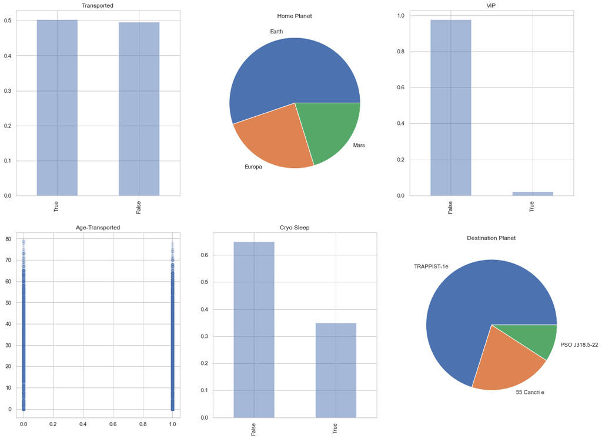

```python
fig = plt.figure(figsize=(20, 15))

plt.subplot2grid((2,3), (0,0))
train_df.Transported.value_counts(normalize=True).plot(kind='bar', alpha=0.5)
plt.title("Transported")

plt.subplot2grid((2,3), (0,1))
train_df.HomePlanet.value_counts(normalize=True).plot(kind='pie', label = '')
plt.title("Home Planet")

plt.subplot2grid((2,3), (0,2))
train_df.VIP.value_counts(normalize=True).plot(kind='bar', alpha = 0.5)
plt.title("VIP")

plt.subplot2grid((2,3), (1,0))
plt.scatter(train_df.Transported, train_df.Age, alpha=0.1)
plt.title("Age-Transported")

plt.subplot2grid((2,3), (1,1))
train_df.CryoSleep.value_counts(normalize=True).plot(kind='bar', alpha=0.5)
plt.title("Cryo Sleep")

plt.subplot2grid((2,3), (1,2))
train_df.Destination.value_counts(normalize=True).plot(kind='pie', label = '')
plt.title("Destination Planet")

plt.show()
```

Let's look a bit further into the ages of the passengers to get a better idea

```python
ages = train_df[train_df['Age']>0]
fig = px.histogram(ages,x='Age',nbins=20, title="Distribution of Ages in train data")
fig.show()
```

[interactive chart not shown]

Visualizations for test data:

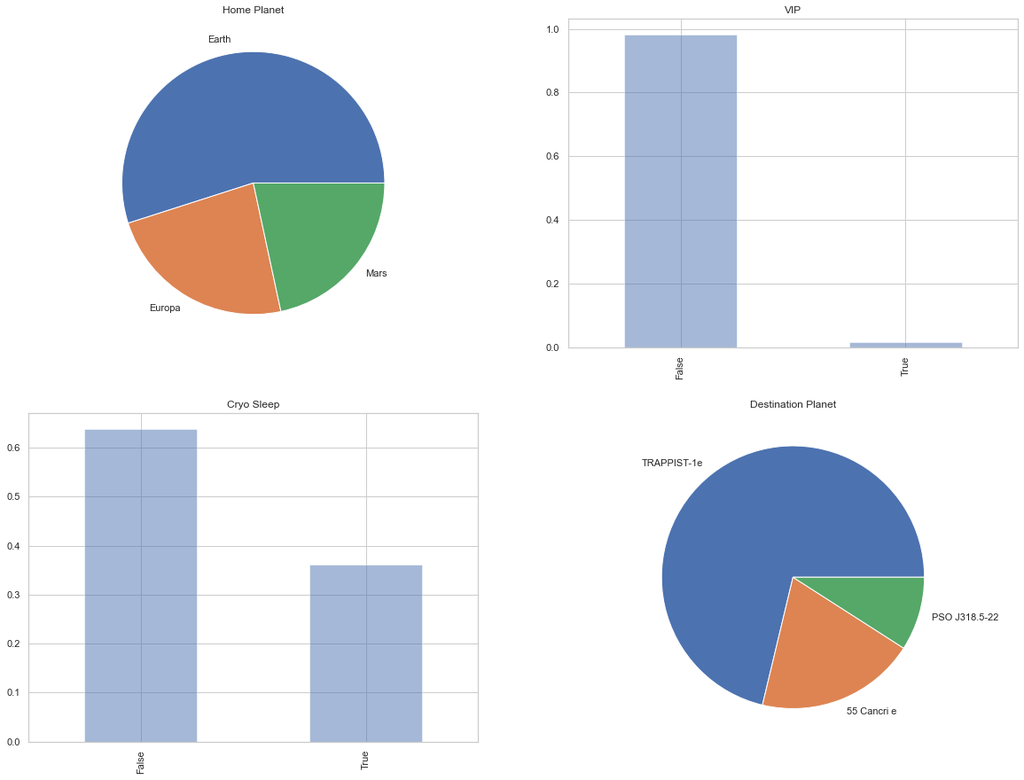

```python
fig = plt.figure(figsize=(20, 15))


plt.subplot2grid((2,2), (0,0))
test_df.HomePlanet.value_counts(normalize=True).plot(kind='pie', label = '')
plt.title("Home Planet")

plt.subplot2grid((2,2), (0,1))
test_df.VIP.value_counts(normalize=True).plot(kind='bar', alpha = 0.5)
plt.title("VIP")


plt.subplot2grid((2,2), (1,0))
test_df.CryoSleep.value_counts(normalize=True).plot(kind='bar', alpha=0.5)
plt.title("Cryo Sleep")

plt.subplot2grid((2,2), (1,1))
test_df.Destination.value_counts(normalize=True).plot(kind='pie', label = '')
plt.title("Destination Planet")

plt.show()
```

```python
ages = test_df[test_df['Age']>0]
fig = px.histogram(ages,x='Age',nbins=20, title="Distribution of Ages in test data")
fig.show()
```

[interactive chart not shown]

Visualizations for both sets look the same aside from the test data not having the including the transport status. A few things to highlight:

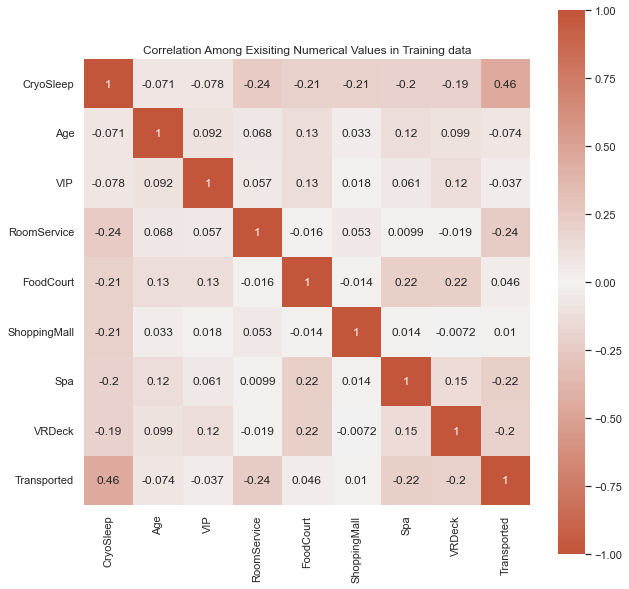

```python
sns.set(rc={'figure.figsize':(10,10)})
corr = train_df.corr()
ax = sns.heatmap( corr,vmin=-1, vmax=1, center=0, cmap=sns.diverging_palette(20, 20, n=200),annot=True, square=True)
plt.title("Correlation Among Exisiting Numerical Values in Training data")
plt.show()
```

Remarks:

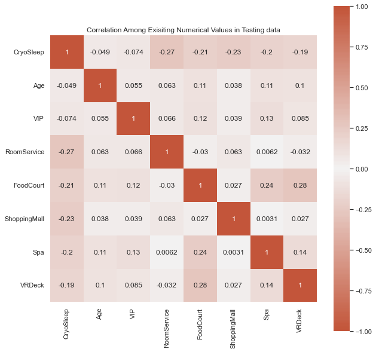

```python
sns.set(rc={'figure.figsize':(10,10)})
corr = test_df.corr()
ax = sns.heatmap( corr,vmin=-1, vmax=1, center=0, cmap=sns.diverging_palette(20, 20, n=200),annot=True, square=True)
plt.title("Correlation Among Exisiting Numerical Values in Testing data")
plt.show()
```

Remark:

Since almost all of the passengers are not VIP, we will remove the column. The only inidication of wealth status can be found in the bill totals of the passengers. We will also remove the name, passenger ID and cabin number since they all hold completely unqiue values that do not necessarily give us any relevant insight since we are looking at the passengers as a group, not individuals.

```python
train_df.drop(['VIP', 'Cabin', 'Name','PassengerId'], axis=1, inplace=True)
test_df.drop(['VIP','Cabin', 'Name','PassengerId'], axis=1, inplace=True)
```

We will label encode categorical values (converting each category to a number)

```python
train_df['HomePlanet'] = train_df['HomePlanet'].astype('category')
train_df['HomePlanet'] = train_df['HomePlanet'].cat.codes
train_df['Destination'] = train_df['Destination'].astype('category')
train_df['Destination'] = train_df['Destination'].cat.codes
train_df['CryoSleep'] = train_df['CryoSleep'].astype('category')
train_df['CryoSleep'] = train_df['CryoSleep'].cat.codes
train_df['Transported'] = train_df['Transported'].astype('category')
train_df['Transported'] = train_df['Transported'].cat.codes

test_df['HomePlanet'] = test_df['HomePlanet'].astype('category')
test_df['HomePlanet'] = test_df['HomePlanet'].cat.codes
test_df['Destination'] = test_df['Destination'].astype('category')
test_df['Destination'] = test_df['Destination'].cat.codes
test_df['CryoSleep'] = test_df['CryoSleep'].astype('category')
test_df['CryoSleep'] = test_df['CryoSleep'].cat.codes
```

We need to standardize Age and the bill totals to make sure they do not carry any unfair weight when running the algorithms

```python
scaler = StandardScaler()

train_df['Age'] = scaler.fit_transform(train_df[['Age']])
train_df['ShoppingMall'] = scaler.fit_transform(train_df[['ShoppingMall']])
train_df['FoodCourt'] = scaler.fit_transform(train_df[['FoodCourt']])
train_df['RoomService'] = scaler.fit_transform(train_df[['RoomService']])
train_df['Spa'] = scaler.fit_transform(train_df[['Spa']])
train_df['VRDeck'] = scaler.fit_transform(train_df[['VRDeck']])

test_df['Age'] = scaler.fit_transform(test_df[['Age']])
test_df['ShoppingMall'] = scaler.fit_transform(test_df[['ShoppingMall']])
test_df['FoodCourt'] = scaler.fit_transform(test_df[['FoodCourt']])
test_df['RoomService'] = scaler.fit_transform(test_df[['RoomService']])
test_df['Spa'] = scaler.fit_transform(test_df[['Spa']])
test_df['VRDeck'] = scaler.fit_transform(test_df[['VRDeck']])
```

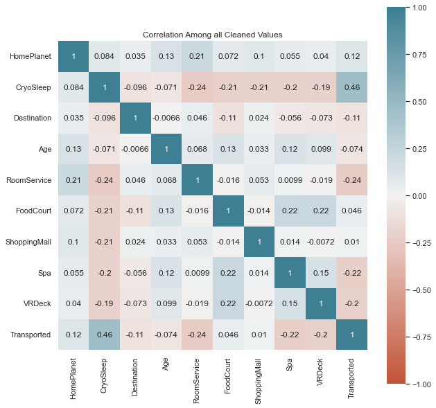

```python
sns.set(rc={'figure.figsize':(10,10)})
corr = train_df.corr()
ax = sns.heatmap( corr,vmin=-1, vmax=1, center=0, cmap=sns.diverging_palette(20, 220, n=200),annot=True, square=True)
plt.title("Correlation Among all Cleaned Values")
plt.show()
```

Remark:

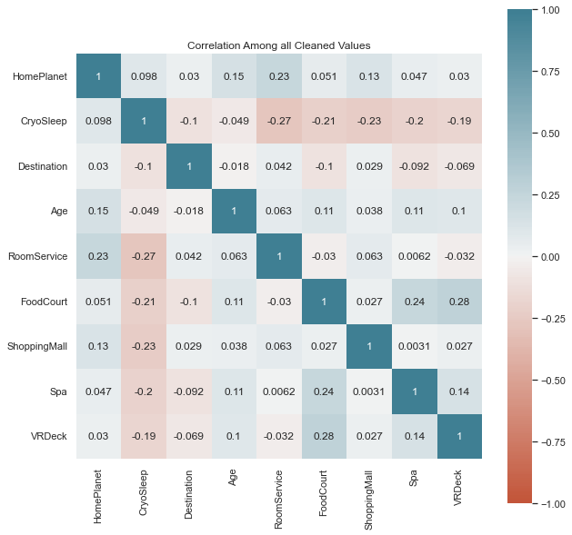

```python
sns.set(rc={'figure.figsize':(10,10)})
corr = test_df.corr()
ax = sns.heatmap( corr,vmin=-1, vmax=1, center=0, cmap=sns.diverging_palette(20, 220, n=200),annot=True, square=True)
plt.title("Correlation Among all Cleaned Values")
plt.show()
```

Remark:

Since we are intersted in the which passengers were transported and which were not we will focus on using on the train data set since it contains those values. We will now split the data into train and test groups where the test size is 20%.

```python
X = train_df.drop('Transported',axis=1)
y = train_df['Transported']
X_train, X_test, y_train, y_test = train_test_split(X, y, test_size=0.2, random_state=100)
```

### Part 3: Algorithms

We will be needing a confusion matrix for each algorithm so we will define a function now for it and call it when needed

```python
def print_conf_matrix(title, conf_matrix):


    group_names = ['True Neg','False Pos','False Neg','True Pos']
    group_counts = ["{0:0.0f}".format(value) for value in
                    conf_matrix.flatten()]
    group_percentages = ["{0:.2%}".format(value) for value in
                         conf_matrix.flatten()/np.sum(conf_matrix)]
    labels = [f"{v1}\n{v2}\n{v3}" for v1, v2, v3 in
              zip(group_names,group_counts,group_percentages)]
    labels = np.asarray(labels).reshape(2,2)

    ax = sns.heatmap(conf_matrix, annot=labels, fmt='', cmap='Greens')
    #ax.set_title('Confusion Matrix for Logistic Regression\n\n');
    ax.set_title(title);
    ax.set_xlabel('\nPredicted Values')
    ax.set_ylabel('Actual Values ');
    ax.xaxis.set_ticklabels(['False','True'])
    ax.yaxis.set_ticklabels(['False','True'])
    plt.show()
```

#### Logistic Regression - Ndumo

Implementation:

```
Acurracy for train set: 78.40%

Accuracy on test set: 79.18%


Classification Report for Logistic Regression
              precision    recall  f1-score   support

           0       0.82      0.76      0.79       885
           1       0.77      0.82      0.79       854

    accuracy                           0.79      1739
   macro avg       0.79      0.79      0.79      1739
weighted avg       0.79      0.79      0.79      1739
```

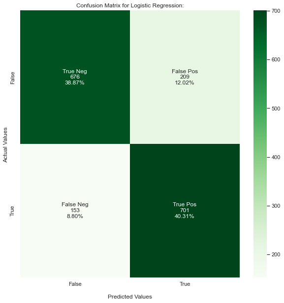

```python
log_reg = LogisticRegression(C=10.0)
log_reg.fit(X_train, y_train)
Y_pred_log_reg = log_reg.predict(X_test)
accuracy_log_reg1 = round( log_reg.score(X_train, y_train) * 100, 2)
print('Acurracy for train set: {0:.2f}%\n'.format(accuracy_log_reg1))
accuracy_log_reg = round( log_reg.score(X_test, y_test) * 100, 2)
print('Accuracy on test set: {0:.2f}%\n'.format(accuracy_log_reg))
print()
print(f'Classification Report for Logistic Regression \n{classification_report(y_test, Y_pred_log_reg)}')
print_conf_matrix("Confusion Matrix for Logistic Regression:",confusion_matrix(y_test, Y_pred_log_reg))
```

```python
conf_matrix = confusion_matrix(y_test, Y_pred_log_reg)

group_names = ['True Neg','False Pos','False Neg','True Pos']
group_counts = ["{0:0.0f}".format(value) for value in
                conf_matrix.flatten()]
group_percentages = ["{0:.2%}".format(value) for value in
                     conf_matrix.flatten()/np.sum(conf_matrix)]
labels = [f"{v1}\n{v2}\n{v3}" for v1, v2, v3 in
          zip(group_names,group_counts,group_percentages)]
labels = np.asarray(labels).reshape(2,2)

TN = conf_matrix[0,0]
FN = conf_matrix[1,0]
TP = conf_matrix[1,1]
FP = conf_matrix[0,1]
TPR = (TP/(TP+FN)) * 100
TNR = (TN/(FP+TN)) * 100

print("Percent of passengers transported to another dimension correctly predicted: {0:.2f}%\n".format(round(TPR, 2)))
print("Percent of passengers not transported to another dimension: {0:.2f}%\n".format(round(TNR, 2)))
```

```
Percent of passengers transported to another dimension correctly predicted: 82.08%

Percent of passengers not transported to another dimension: 76.38%
```

#### Gausian Naive Bayes - Anna

Implementation:

```
Accuracy using train data 70.65
Accuracy using test data 70.04

Classification Report for Naive Bayes
              precision    recall  f1-score   support

           0       0.87      0.49      0.62       885
           1       0.63      0.92      0.75       854

    accuracy                           0.70      1739
   macro avg       0.75      0.70      0.69      1739
weighted avg       0.75      0.70      0.69      1739
```

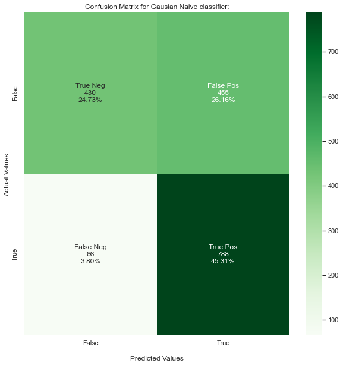

```python
g_classifier = GaussianNB()
g_classifier.fit(X_train, y_train)
Y_pred_g = g_classifier.predict(X_test)
acc_g_classifier1 = round(g_classifier.score(X_train, y_train) * 100, 2)
print("Accuracy using train data", acc_g_classifier1)
acc_g_classifier = round(g_classifier.score(X_test, y_test) * 100, 2)
print("Accuracy using test data", acc_g_classifier)
print()
print(f'Classification Report for Naive Bayes \n{classification_report(y_test, Y_pred_g)}')
print_conf_matrix("Confusion Matrix for Gausian Naive classifier:",confusion_matrix(y_test, Y_pred_g))
```

```python
conf_matrix = confusion_matrix(y_test, Y_pred_g)

group_names = ['True Neg','False Pos','False Neg','True Pos']
group_counts = ["{0:0.0f}".format(value) for value in
                conf_matrix.flatten()]
group_percentages = ["{0:.2%}".format(value) for value in
                     conf_matrix.flatten()/np.sum(conf_matrix)]
labels = [f"{v1}\n{v2}\n{v3}" for v1, v2, v3 in
          zip(group_names,group_counts,group_percentages)]
labels = np.asarray(labels).reshape(2,2)

TN = conf_matrix[0,0]
FN = conf_matrix[1,0]
TP = conf_matrix[1,1]
FP = conf_matrix[0,1]
TPR = (TP/(TP+FN)) * 100
TNR = (TN/(FP+TN)) * 100
print("Percent of passengers transported to another dimension correctly predicted: {0:.2f}%\n".format(round(TPR, 2)))
print("Percent of passengers not transported to another dimension: {0:.2f}%\n".format(round(TNR, 2)))
```

```
Percent of passengers transported to another dimension correctly predicted: 92.27%

Percent of passengers not transported to another dimension: 48.59%
```

Permuation Importance - Anna

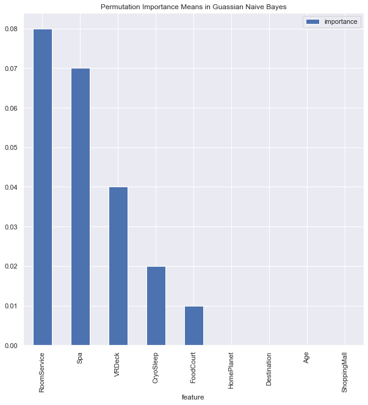

```python
imps = permutation_importance(g_classifier, X_test, y_test)
feature_importance = pd.DataFrame({'feature':X_train.columns,'importance':np.round(imps.importances_mean,2)})
feature_importance = feature_importance.sort_values('importance',ascending=False).set_index('feature')
feature_importance.plot.bar()
plt.title("Permutation Importance Means in Guassian Naive Bayes")
plt.show()
```

Although Home Planet, Destination, Age and Shopping Mall Bill are all 0, we'll just remove Age and Shopping Mall since in our correlation heatmap, they have the weakest correlation.

```python
X2 = train_df.drop(['Age','ShoppingMall'],axis=1)
y2 = train_df['Transported']
X_train2, X_test2, y_train2, y_test2 = train_test_split(X2, y2, test_size=0.2, random_state=100)
```

We will just check accuracy score first with new data

```python
g_classifier = GaussianNB()
g_classifier.fit(X_train2, y_train2)
Y_pred_g = g_classifier.predict(X_test2)
acc_g_classifier3 = round(g_classifier.score(X_train2, y_train2) * 100, 2)
print("Accuracy using train data", acc_g_classifier3)
acc_g_classifier4 = round(g_classifier.score(X_test2, y_test2) * 100, 2)
print("Accuracy using test data", acc_g_classifier4)
```

```
Accuracy using train data 100.0
Accuracy using test data 100.0
```

#### Decision Tree - Papia

Implementation:

```python
decision_tree = DecisionTreeClassifier()
param_grid = { 'criterion':['gini','entropy'],'max_leaf_nodes': np.arange(1, 10)}
decision_tree = GridSearchCV(decision_tree, param_grid, cv=9)
decision_model = decision_tree.fit(X_train, y_train)
print("Best parameters: ", decision_tree.best_params_)

dot_data = export_graphviz(decision_tree.best_estimator_, out_file=None,
            filled=True, rounded=True, feature_names=train_df.columns[1:], class_names=['0','1'])
graph = graphviz.Source(dot_data)
graph
```

```
Best parameters:  {'criterion': 'gini', 'max_leaf_nodes': 9}
```

[figure not shown]

```
Accuracy on train set: 77.35%

Accuracy on test set: 77.34%


Classification Report for Decision Tree
              precision    recall  f1-score   support

           0       0.83      0.69      0.76       885
           1       0.73      0.86      0.79       854

    accuracy                           0.77      1739
   macro avg       0.78      0.77      0.77      1739
weighted avg       0.78      0.77      0.77      1739
```

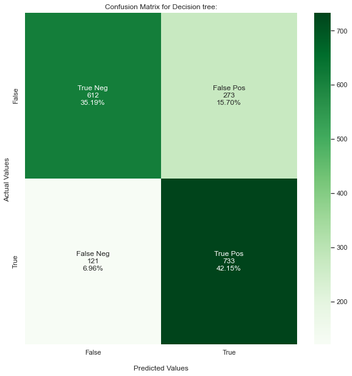

```python
Y_pred_d = decision_tree.predict(X_test)
acc_decision_tree1 = round(decision_tree.score(X_train, y_train) * 100, 2)
print('Accuracy on train set: {0:.2f}%\n'.format(acc_decision_tree1))
acc_decision_tree = round(decision_tree.score(X_test, y_test) * 100, 2)
print('Accuracy on test set: {0:.2f}%\n'.format(acc_decision_tree))
print()
print(f'Classification Report for Decision Tree \n{classification_report(y_test, Y_pred_d)}')
print_conf_matrix("Confusion Matrix for Decision tree:",confusion_matrix(y_test, Y_pred_d))
```

```python
conf_matrix = confusion_matrix(y_test, Y_pred_d)

group_names = ['True Neg','False Pos','False Neg','True Pos']
group_counts = ["{0:0.0f}".format(value) for value in
                conf_matrix.flatten()]
group_percentages = ["{0:.2%}".format(value) for value in
                     conf_matrix.flatten()/np.sum(conf_matrix)]
labels = [f"{v1}\n{v2}\n{v3}" for v1, v2, v3 in
          zip(group_names,group_counts,group_percentages)]
labels = np.asarray(labels).reshape(2,2)

TN = conf_matrix[0,0]
FN = conf_matrix[1,0]
TP = conf_matrix[1,1]
FP = conf_matrix[0,1]
TPR = (TP/(TP+FN)) * 100
TNR = (TN/(FP+TN)) * 100
print("Percent of passengers transported to another dimension correctly predicted: {0:.2f}%\n".format(round(TPR, 2)))
print("Percent of passengers not transported to another dimension: {0:.2f}%\n".format(round(TNR, 2)))
```

```
Percent of passengers transported to another dimension correctly predicted: 85.83%

Percent of passengers not transported to another dimension: 69.15%
```

### Random Forest - Papia

Implementation:

```
Accuracy on train set: 93.66%

Accuracy on test set: 78.26%


Classification Report for Random Forest
              precision    recall  f1-score   support

           0       0.79      0.78      0.78       885
           1       0.77      0.79      0.78       854

    accuracy                           0.78      1739
   macro avg       0.78      0.78      0.78      1739
weighted avg       0.78      0.78      0.78      1739
```

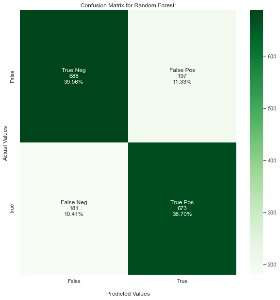

```python
random_forest = RandomForestClassifier()
random_forest.fit(X_train, y_train)
Y_pred_r = random_forest.predict(X_test)
acc_random_forest1 = round(random_forest.score(X_train, y_train) * 100, 2)
print('Accuracy on train set: {0:.2f}%\n'.format(acc_random_forest1))
acc_random_forest = round(random_forest.score(X_test, y_test) * 100, 2)
print('Accuracy on test set: {0:.2f}%\n'.format(acc_random_forest))
print()
print(f'Classification Report for Random Forest \n{classification_report(y_test, Y_pred_r)}')
print_conf_matrix("Confusion Matrix for Random Forest:",confusion_matrix(y_test, Y_pred_r))
```

```python
conf_matrix = confusion_matrix(y_test, Y_pred_r)

group_names = ['True Neg','False Pos','False Neg','True Pos']
group_counts = ["{0:0.0f}".format(value) for value in
                conf_matrix.flatten()]
group_percentages = ["{0:.2%}".format(value) for value in
                     conf_matrix.flatten()/np.sum(conf_matrix)]
labels = [f"{v1}\n{v2}\n{v3}" for v1, v2, v3 in
          zip(group_names,group_counts,group_percentages)]
labels = np.asarray(labels).reshape(2,2)

TN = conf_matrix[0,0]
FN = conf_matrix[1,0]
TP = conf_matrix[1,1]
FP = conf_matrix[0,1]
TPR = (TP/(TP+FN)) * 100
TNR = (TN/(FP+TN)) * 100

print("Percent of passengers transported to another dimension correctly predicted: {0:.2f}%\n".format(round(TPR, 2)))
print("Percent of passengers not transported to another dimension: {0:.2f}%\n".format(round(TNR, 2)))
```

```
Percent of passengers transported to another dimension correctly predicted: 79.04%

Percent of passengers not transported to another dimension: 78.19%
```

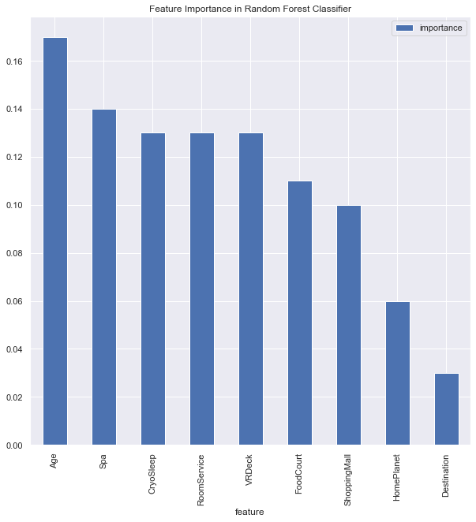

```python
feature_importance = pd.DataFrame({'feature':X_train.columns,'importance':np.round(random_forest.feature_importances_,2)})
feature_importance = feature_importance.sort_values('importance',ascending=False).set_index('feature')
feature_importance.plot.bar()
plt.title("Feature Importance in Random Forest Classifier")
plt.show()
```

```python
X3 = train_df.drop(['Destination','HomePlanet'],axis=1)
y3 = train_df['Transported']
X_train3, X_test3, y_train3, y_test3 = train_test_split(X3, y3, test_size=0.2, random_state=100)
```

```python
random_forest2 = RandomForestClassifier()
random_forest2.fit(X_train3, y_train3)
Y_pred_r = random_forest2.predict(X_test3)
acc_random_forest2 = round(random_forest.score(X_train3, y_train3) * 100, 2)
print('Accuracy on train set: {0:.2f}%\n'.format(acc_random_forest2))
acc_random_forest3 = round(random_forest.score(X_test3, y_test3) * 100, 2)
print('Accuracy on test set: {0:.2f}%\n'.format(acc_random_forest3))
```

[output not shown]

Same issue as Niave Bayes- most likely overfitting the data